# Forecasting # of visitors from Japan

### CMV

```r
source("source.R")
TS_SE1 <- read.csv("Japan.csv")
Visitors <- TS_SE1$Japan
Quarter <- TS_SE1$Month
Season <- max(Quarter)
Period <- TS_SE1$period
t  = Period -1
n <- length(Visitors)
CMV_SI <- Center_Moving_Average(Visitors, Quarter, Season)
cat("# # # # The Centered moving average seasonal index # # # ","\n")
```

```
# # # # The Centered moving average seasonal index # # #
```

```r
print(CMV_SI)
```

```
 [1] 0.9214070 0.9582428 1.2596817 0.8657040 0.9220580 0.8520871 0.8459173 1.0762823 1.0432899
[10] 1.0319428 1.1174021 1.1059850
```

### Forecast by seasonal index

```
### Linear Model ###
Call:
lm(formula = Des_x ~ t)

Residuals:
   Min     1Q Median     3Q    Max
-33591  -6211   -284   7211  28594

Coefficients:
            Estimate Std. Error t value Pr(>|t|)
(Intercept) 78362.28    1769.29   44.29   <2e-16 ***
t             725.94      23.35   31.09   <2e-16 ***
---
Signif. codes:  0 ‘***’ 0.001 ‘**’ 0.01 ‘*’ 0.05 ‘.’ 0.1 ‘ ’ 1

Residual standard error: 10220 on 130 degrees of freedom
Multiple R-squared:  0.8815,    Adjusted R-squared:  0.8805
F-statistic: 966.7 on 1 and 130 DF,  p-value: < 2.2e-16


    Shapiro-Wilk normality test

data:  Standard_E
W = 0.99193, p-value = 0.6509

run test:[1] 2.741969e-05
The Outliers[1]   2  46  82 100 118 130
influential observations:[1] "no influential observations"
mean_y: 125911.1



deseasonalized data:
  [1]  91797.92 100954.47  94809.50  78202.53  86951.87  92286.13  86206.21  81319.37  76099.92
 [10] 103756.59  83632.24  91614.45  74856.47  72443.30  85889.01  74825.16  96016.46  84773.11
 [19]  75858.99  81465.84  93567.77  77108.85  89094.73  91940.20  92998.49  97180.21  92730.10
 [28]  85119.86  87973.63  88090.16  94445.85  91678.46 109824.43 111631.42  90778.49 100199.37
 [37]  95421.33 106901.05 111132.61 109404.38 117808.10 108969.22 116822.76 116431.96 101559.89
 [46] 139623.28 120845.61 127425.77 126052.81 127256.95 119790.67 121698.55 116419.23 114343.55
 [55] 112715.02 108522.27 118158.42 108094.74 118937.98 118680.29 112578.61 107715.52 118431.20
 [64] 119610.81 116837.14 124808.28 123822.03 129275.71 122965.20 142608.95 129761.35 134653.41
 [73] 144717.58 140475.08 138978.12 138003.75 134741.08 137326.41 136182.84 136637.48 131874.40
 [82] 108734.45 132631.92 128249.38 134985.01 138666.58 133740.02 133366.49 139783.78 144872.37
 [91] 142680.06 153135.89 155282.08 138776.94 157773.19 149553.43 157721.10 152768.42 158165.58
[100] 173806.62 151279.15 162156.28 166497.80 166150.54 140440.65 154562.08 157042.85 146368.73
[109] 158535.59 166617.95 155142.82 160035.14 157570.78 155373.93 172711.32 169493.26 175722.56
[118] 129706.17 163477.81 146860.82 163686.02 157432.27 152926.29 173909.76 156335.27 176169.65
[127] 181913.02 180922.89 158653.01 151238.29 171320.26 192171.92
```

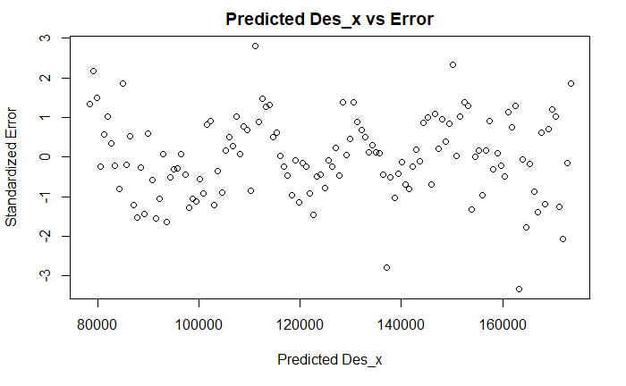

```r
Forecast_Visitors_CMV= Forecast_by_SI(Visitors, Quarter, Season, CMV_SI, t)
```

```r
cat("# # # # The Forecast_Visitors_y # # # ","\n")
```

```
# # # # The Forecast_Visitors_y # # #
```

```r
print(Forecast_Visitors_CMV)
```

```
  [1]  72254.57  67390.05  67516.18  86683.88  84784.02  84611.01  92429.16  92287.63  77554.62
 [10]  81350.70 107856.01  74751.44  80286.83  74812.78  74885.16  96059.62  93872.36  93600.50
 [19] 102163.10 101922.11  85581.20  89698.17 118829.39  82292.79  88319.08  82235.50  82254.13
 [28] 105435.36 102960.69 102589.99 111897.05 111556.60  93607.79  98045.64 129802.76  89834.13
 [37]  96351.34  89658.22  89623.11 114811.10 112049.03 111579.48 121630.99 121191.09 101634.38
 [46] 106393.11 140776.14  97375.48 104383.60  97080.95  96992.09 124186.84 121137.36 120568.97
 [55] 131364.93 130825.58 109660.96 114740.58 151749.51 104916.82 112415.85 104503.67 104361.07
 [64] 133562.58 130225.70 129558.46 141098.88 140460.06 117687.55 123088.05 162722.88 112458.17
 [73] 120448.11 111926.40 111730.05 142938.32 139314.04 138547.94 150832.82 150094.55 125714.14
 [82] 131435.52 173696.26 119999.51 128480.37 119349.12 119099.03 152314.06 148402.37 147537.43
 [91] 160566.77 159729.04 133740.72 139782.99 184669.63 127540.86 136512.62 126771.85 126468.00
[100] 161689.80 157490.71 156526.92 170300.71 169363.52 141767.31 148130.46 195643.01 135082.20
[109] 144544.88 134194.57 133836.98 171065.54 166579.04 165516.41 180034.66 178998.01 149793.90
[118] 156477.94 206616.38 142623.54 152577.14 141617.30 141205.96 180441.28 175667.38 174505.90
[127] 189768.60 188632.50 157820.48 164825.41 217589.76 150164.89 160496.01 167607.90 221247.55
[136] 152678.67 163286.81 151514.26 151031.27 192942.27 187785.16 186491.88 202747.19 201478.48
```

```r
t2 = c(t,n,n+1,n+2,n+3,n+4,n+5,n+6,n+7,n+8,n+9,n+10,n+11)
lines(t,Visitors, col = "blue", main = "Visitorsagainst Period", xlab = "Period", ylab = "Tourists")
lines(t, Visitors, type="o", col = "blue")    #actual
```

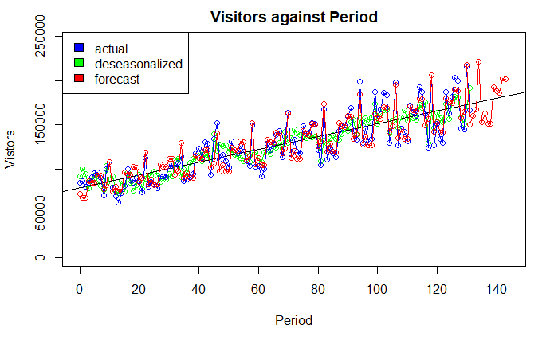

```r
lines(t2,Forecast_Visitors_CMV, type="o", col = "red")  #forecast
legend("topleft", c("actual", "deseasonalized", "forecast"), fill=c("blue","green", "red"))
```

*Residual analysis:*  
Dependence of the Error Variable  
H0 : Randomness exists.  
H1 : Randomness does not exist.  
Since pvalue = 2.741969e-05 < 0.05, wereject H0. Therefore we do not use this method to forecast the # of visitors from Japan.

## Smoothing by Linear Regression Model

```r
SLR_SI <- Linear_Regression_Seasonal_Index(Visitors, Quarter, Season)
cat("# # # # The Simple Linear_Regression seasonal index # # # ","\n")
```

```
# # # # The Simple Linear_Regression seasonal index # # #
```

```r
print(SLR_SI)
```

```
 [1] 0.9065778 0.9431494 1.2489661 0.8667965 0.9311954 0.8695664 0.8563085 1.0674273 1.0415225
[10] 1.0362937 1.1239475 1.1082489
```

### Forecast by seasonal index

```
### Linear Model ###
Call:
lm(formula = Des_x ~ t)

Residuals:
   Min     1Q Median     3Q    Max
-31552  -6207     96   6705  30904

Coefficients:
            Estimate Std. Error t value Pr(>|t|)
(Intercept) 78216.03    1755.29   44.56   <2e-16 ***
t             727.50      23.16   31.41   <2e-16 ***
---
Signif. codes:  0 ‘***’ 0.001 ‘**’ 0.01 ‘*’ 0.05 ‘.’ 0.1 ‘ ’ 1

Residual standard error: 10140 on 130 degrees of freedom
Multiple R-squared:  0.8836,    Adjusted R-squared:  0.8827
F-statistic: 986.4 on 1 and 130 DF,  p-value: < 2.2e-16


    Shapiro-Wilk normality test

data:  Standard_E
W = 0.9941, p-value = 0.8631

run test:[1] 0.0001208429
The Outliers[1]  10  46  82 100 118
influential observations:[1] "no influential observations"
mean_y: 125867.6



deseasonalized data:
  [1]  90897.14  98925.16  93659.00  78851.27  87099.41  91898.65  85704.18  81153.25  77344.72
 [10] 105417.02  84349.77  91498.98  74121.93  70987.10  84846.75  75445.89  96179.39  84417.19
 [19]  75417.23  81299.42  95098.30  78342.84  89859.12  91824.32  92085.94  95226.77  91604.83
 [28]  85825.99  88122.91  87720.30  93895.85  91491.18 111620.87 113417.88  91557.33 100073.09
 [37]  94485.00 104752.21 109784.03 110311.97 118008.01 108511.71 116142.44 116194.11 103221.15
 [46] 141857.70 121882.41 127265.17 124815.91 124698.93 118337.02 122708.13 116616.78 113863.47
 [55] 112058.62 108300.58 120091.19 109824.60 119958.42 118530.70 111473.92 105550.31 116994.04
 [64] 120603.07 117035.39 124284.26 123100.95 129011.63 124976.59 144891.15 130874.65 134483.70
 [73] 143297.53 137651.36 137291.63 139148.59 134969.72 136749.84 135389.78 136358.35 134031.53
 [82] 110474.55 133769.84 128087.73 133660.45 135879.21 132117.10 134472.86 140020.97 144264.12
 [91] 141849.16 152823.07 157822.09 140997.81 159126.82 149364.93 156173.45 149697.60 156246.25
[100] 175248.48 151535.85 161475.45 165528.20 165811.12 142737.89 157035.57 158390.21 146184.25
[109] 156979.94 163268.73 153260.18 161362.75 157838.16 154721.58 171705.53 169147.01 178596.93
[118] 131781.88 164880.38 146675.72 162079.84 154267.69 151070.55 175352.46 156600.55 175429.99
[127] 180853.65 180553.30 161248.17 153658.59 172790.12 191929.71
```

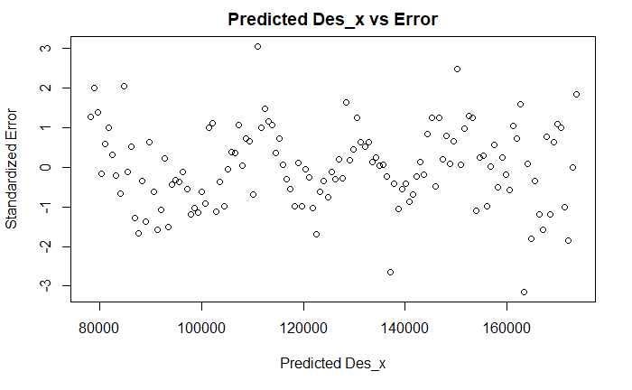

```r
Forecast_Visitors_SLR <- Forecast_by_SI(Visitors, Quarter, Season, SLR_SI, t)
```

```r
#cat("# # # # The Forecast_Visitors_y # # # ","\n")
#print(Forecast_Visitors_SLR)
lines(t, Visitors, type="o", col = "blue")    #actual
lines(t2,Forecast_Visitors_SLR, type="o", col = "red")  #forecast
```

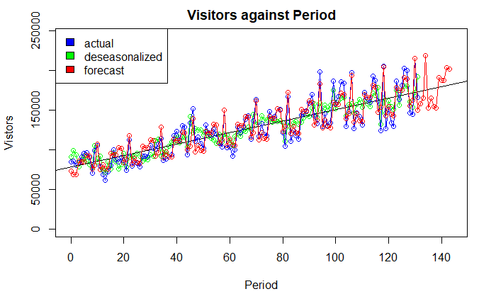

```r
legend("topleft", c("actual", "deseasonalized", "forecast"), fill=c("blue","green", "red"))
```

*Residual analysis:*  
Dependence of the Error Variable  
H0 : Randomness exists.  
H1 : Randomness does not exist.  
Since the pvalue of run test = 0.0001 < 0.05, we reject H0. Therefore we do not use this method to forecast the number of visitors from Japan.

## Regression model by indicator variables

### The Regression Model

y = beta0 + beta1*t + beta2*Q1 + beta3*Q2 + beta4*Q3 + beta5*Q4 +beta6*Q5 +beta7*Q6 +beta8*Q7 +beta*9Q8 +beta10*Q9 +beta11*Q10 +vbeta12Q*11 +e where t = time in chronological order Qi = indicator variable (0, 1).

### Dummy as Quarter

```r
Dummy_I <- Season - 1    # n-1 indicator variables
Q <- matrix(nrow =n, ncol = Dummy_I)
Dummy_Name <- vector("character", length = Dummy_I)
for(i in 1:Dummy_I){
  Dummy_Name[i] <- paste0("Q", i)
}
colnames(Q) <- Dummy_Name
for(i in 1:n){
  for(j in 1:Dummy_I){
    if(Quarter[i] == j){
      Q[i,j] <- 1
    } else {
      Q[i,j] <- 0
    }
  }
}
```

### build the model

```r
Data.Visitors <- cbind(t, Q)  #t, Q1, Q2, Q3...
linearModelVar1 <- lm(Visitors ~ Data.Visitors)
cat("\n# # # # The regression model # # # ","\n")
```

```
# # # # The regression model # # #
```

```r
print(summary(linearModelVar1))
```

```
Call:
lm(formula = Visitors ~ Data.Visitors)

Residuals:
   Min     1Q Median     3Q    Max
-30005  -7843    167   7453  32467

Coefficients:
                  Estimate Std. Error t value Pr(>|t|)
(Intercept)       92983.23    3960.76  23.476  < 2e-16 ***
Data.Visitorst      735.67      26.84  27.405  < 2e-16 ***
Data.VisitorsQ1  -27066.76    4990.60  -5.424 3.11e-07 ***
Data.VisitorsQ2  -24762.07    4990.81  -4.962 2.35e-06 ***
Data.VisitorsQ3   17594.53    4991.18   3.525 0.000602 ***
Data.VisitorsQ4  -32854.05    4991.68  -6.582 1.31e-09 ***
Data.VisitorsQ5  -23681.02    4994.06  -4.742 5.93e-06 ***
Data.VisitorsQ6  -31858.69    4993.12  -6.381 3.52e-09 ***
Data.VisitorsQ7  -33875.27    4992.33  -6.785 4.78e-10 ***
Data.VisitorsQ8   -5481.86    4991.68  -1.098 0.274335
Data.VisitorsQ9  -10914.89    4991.18  -2.187 0.030710 *
Data.VisitorsQ10 -10479.84    4990.81  -2.100 0.037857 *
Data.VisitorsQ11   1678.40    4990.60   0.336 0.737228
---
Signif. codes:  0 ‘***’ 0.001 ‘**’ 0.01 ‘*’ 0.05 ‘.’ 0.1 ‘ ’ 1

Residual standard error: 11700 on 119 degrees of freedom
Multiple R-squared:  0.8952,    Adjusted R-squared:  0.8846
F-statistic: 84.67 on 12 and 119 DF,  p-value: < 2.2e-16
```

```r
cat(" ","\n")
```

```r
ANOVA_T_lm <- anova(linearModelVar1)
cat("# # # # The ANOVA Table # # # ","\n")
```

```
# # # # The ANOVA Table # # #
```

```r
print(ANOVA_T_lm)
```

```
Analysis of Variance Table

Response: Visitors
               Df     Sum Sq    Mean Sq F value    Pr(>F)
Data.Visitors  12 1.3917e+11 1.1598e+10  84.667 < 2.2e-16 ***
Residuals     119 1.6301e+10 1.3698e+08
---
Signif. codes:  0 ‘***’ 0.001 ‘**’ 0.01 ‘*’ 0.05 ‘.’ 0.1 ‘ ’ 1
```

```r
#residual analysis
SE_1 <- standarized_errors_MR(Visitors, Data.Visitors)[,1]
h_1 <- standarized_errors_MR(Visitors, Data.Visitors)[,2]
D_1 <- standarized_errors_MR(Visitors, Data.Visitors)[,3]
print(shapiro.test(SE_1) )          # normality
```

```
    Shapiro-Wilk normality test

data:  SE_1
W = 0.99747, p-value = 0.9987
```

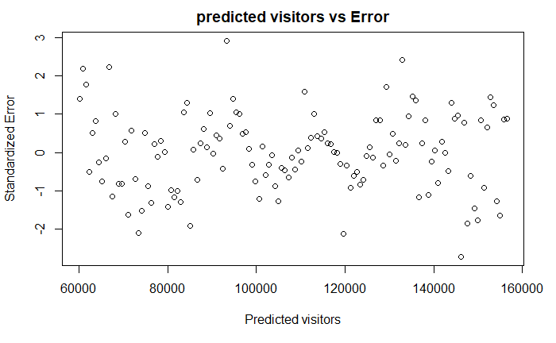

```r
b0<- coef(linearModelVar1)[1]             # Homoscedasticity & Heteroscedasticity
b1 <- coef(linearModelVar1)[2]
b2 <- coef(linearModelVar1)[3]
b3 <- coef(linearModelVar1)[4]
b4 <- coef(linearModelVar1)[5]
b5 <- coef(linearModelVar1)[6]
b6 <- coef(linearModelVar1)[7]
b7 <- coef(linearModelVar1)[8]
b8 <- coef(linearModelVar1)[9]
b9 <- coef(linearModelVar1)[10]
b10 <- coef(linearModelVar1)[11]
b11 <- coef(linearModelVar1)[12]
b12 <- coef(linearModelVar1)[13]
yhat <- vector("double", length = n)
for(i in 1:n) {
       yhat <- b0 + b1 *t + b2 *Q[i,1] + b3 *Q[i,2] + b4 *Q[i,3]+ b5 *Q[i,4]+ b6 *Q[i,5]+ b7 *Q[i,6]+ b8 *Q[i,7]+ b9 *Q[i,8]+ b10 *Q[i,9]+ b11 *Q[i,10]+ b12 *Q[i,11]
}
plot(x = yhat, y = SE_1, xlab = "Predicted visitors", ylab = "Standardized Error", main = "predicted visitors vs Error")
```

```r
cat("\nRun_Test:\n")
```

```
Run_Test:
```

```r
print(Run_Test(SE_1))              #errors are independent
```

```
[1] 0.1621229
```

```r
cat("\nThe Outliers\n")
```

```
The Outliers
```

```r
Outliers <- abs(SE_1) > 2
if(sum(Outliers)!=0){
    print(which(Outliers))
}else{
  print("no outliers")
}
```

```
[1]   2  10  19  46  82 100 118
```

```r
cat("\ninfluential observations:\n")
```

```
influential observations:
```

```r
k <- dim(Data.Visitors)[2]
Inf_Obs <- h_1 > 3*(k+1)/n
if(sum(Inf_Obs)!=0){
    print(which(Inf_Obs))
}else{
  print("no influential observations")
}
```

```
[1] "no influential observations"
```

```r
#assesment
cat("\nmean_y:",mean(Visitors),"\n")
```

```
mean_y: 126028
```

*Residual analysis:*  
1.normality test  
H0: Errors are normally distributed.  
H1: Errors are not normally distributed.  
Since pvalue = 0.9987 > 0.05, we do not reject H0.

2..Homoscedasticity & Heteroscedasticity  
H0: The variance of e is the same for all values of x.  
H1: The variance of e is not the same for all values of x.  
According to the plot, there is no sign of heteroscedasticity.

3.Dependence of the Error Variable  
H0 : Randomness exists.  
H1 : Randomness does not exist.  
Since pvalue = 0.162 > 0.05, we do not reject H0.

*Assessment*  
The standard error of estimate (11700) is samll compared to mean_y (126028 ). We can conclude that the model fit the data.

The F-test of ANOVA: H0: beta1 = beta2 = … = beta11 = 0 H1: At least one betai is not equal to zero. ` since p-value < 2.2e-16 < 0.05, there is sufficient evidence to reject the null hypothesis. At least one of the betai is not equal to zero. Thus, at least one independent variable is related to y. This regression model is valid.

Testing of the Coefficients H0: betai = 0 H1: betai != 0 ` Since all the pvalue except for that of Q8 and Q11 are < 0.05, there is overwhelming evidence to infer that t and all the Qi except for Q8 and Q11 affects the # of visitors.

### Forecast

```r
NoB <- Dummy_I + 2  #b0 ,b1(t), b2(Q1), b3(Q2), b4(Q3)...
bi <- vector("double", length = NoB)
for(i in 1:NoB){
  bi[i] <- coef(linearModelVar1)[i]  #bi[1]:intercept, bi[2]: coefficient of t
}
b0 <- vector("double", length = n)
for(j in 1:n) {
    b0[j] <- 1
}
Data.Visitors_0 <- cbind(b0, Data.Visitors) # matrix[n*NoB]: each bi for all the n samples
y_Dummy <- c(Data.Visitors_0 %*% bi)     # bi[NoB*1]: 1 (*b0), t (*b1), 1or0 (*b2), 1or0 (*b3)...  #only 24 periods
#the next 12 months for
Q1 = bi[1] + bi[2]*133 + bi[3]
Q2 = bi[1] + bi[2]*134 + bi[4]
Q3 = bi[1] + bi[2]*135 + bi[5]
Q4 = bi[1] + bi[2]*136 + bi[6]
Q5 = bi[1] + bi[2]*137 + bi[7]
Q6 = bi[1] + bi[2]*138 + bi[8]
Q7 = bi[1] + bi[2]*139 + bi[9]
Q8 = bi[1] + bi[2]*140 + bi[10]
Q9 = bi[1] + bi[2]*141 + bi[11]
Q10 = bi[1] + bi[2]*142 + bi[12]
Q11 = bi[1] + bi[2]*143 + bi[13]
Q12 =  bi[1] + bi[2]*144   ###
y_Dummy = c(y_Dummy,Q1,Q2,Q3,Q4,Q5,Q6,Q7,Q8,Q9,Q10,Q11,Q12)  #28 periods total
cat("# # # # The Forecast_Visitors_y# # # ","\n")
```

```
# # # # The Forecast_Visitors_y# # #
```

```r
print(y_Dummy)
```

```
  [1]  69302.20  61860.20  60579.30  89708.39  85011.02  86181.75  99075.66  98132.93  71801.84
 [10]  74842.20 117934.48  68221.57  78130.27  70688.27  69407.36  98536.45  93839.09  95009.82
 [19] 107903.73 106961.00  80629.91  83670.27 126762.55  77049.64  86958.34  79516.34  78235.43
 [28] 107364.52 102667.16 103837.89 116731.80 115789.07  89457.98  92498.34 135590.61  85877.70
 [37]  95786.41  88344.41  87063.50 116192.59 111495.23 112665.95 125559.86 124617.14  98286.05
 [46] 101326.41 144418.68  94705.77 104614.48  97172.48  95891.57 125020.66 120323.30 121494.02
 [55] 134387.93 133445.20 107114.11 110154.48 153246.75 103533.84 113442.55 106000.55 104719.64
 [64] 133848.73 129151.36 130322.09 143216.00 142273.27 115942.18 118982.55 162074.82 112361.91
 [73] 122270.61 114828.61 113547.70 142676.80 137979.43 139150.16 152044.07 151101.34 124770.25
 [82] 127810.61 170902.89 121189.98 131098.68 123656.68 122375.77 151504.86 146807.50 147978.23
 [91] 160872.14 159929.41 133598.32 136638.68 179730.95 130018.05 139926.75 132484.75 131203.84
[100] 160332.93 155635.57 156806.30 169700.20 168757.48 142426.39 145466.75 188559.02 138846.11
[109] 148754.82 141312.82 140031.91 169161.00 164463.64 165634.36 178528.27 177585.55 151254.45
[118] 154294.82 197387.09 147674.18 157582.89 150140.89 148859.98 177989.07 173291.70 174462.43
[127] 187356.34 186413.61 160082.52 163122.89 206215.16 156502.25 163760.88 166801.25 209893.52
[136] 160180.61 170089.32 162647.32 161366.41 190495.50 185798.13 186968.86 199862.77 198920.04
```

```r
write.csv(y_Dummy,"../../temp.csv")
t2 = c(t,n,n+1,n+2,n+3,n+4,n+5,n+6,n+7,n+8,n+9,n+10,n+11)
plot(t,Visitors, col = "blue", main = "Visitors against Period", xlab = "Period", ylab = "Vistitors", xlim=range(t2, t2+1), ylim=range(y_Dummy+10000,0))
lines(t, Visitors, type="o", col = "blue")    #actual
```

```r
lines(t2,y_Dummy, type="o", col = "red")  #forecast
abline(lm(Visitors ~ t))
```

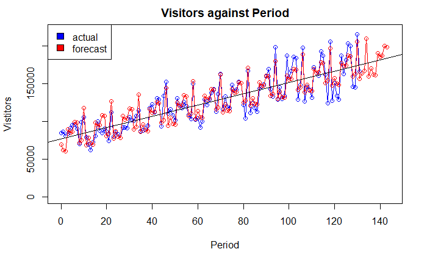

```r
legend("topleft", c("actual", "forecast"), fill=c("blue","red"))
```

The # of visitors forecast for the next 12 months next year are 163760.88, 166801.25, 209893.52, 160180.61, 170089.32, 162647.32, 161366.41, 190495.50, 185798.13, 186968.86, 199862.77, 198920.04 respectively.

## Error Metrics

```r
Dummy_MAD <- Mean_Absolute_Deviation(Visitors, y_Dummy, 1)
Dummy_MSE <- Mean_Square_Error(Visitors, y_Dummy, 1)
Dummy_MAPE <- Mean_Absolute_Percentage_Error(Visitors, y_Dummy, 1)
Error_M <- matrix(nrow = 3, ncol = 1)
colnames(Error_M) = c("Dummy")
rownames(Error_M) = c("MAD", "MSE", "MAPE")
Error_M[1,1] <- Dummy_MAD
Error_M[2,1] <- Dummy_MSE
Error_M[3,1] <- Dummy_MAPE
cat("\n# # # # Error Metrix # # # ","\n")
```

```
# # # # Error Metrix # # #
```

```r
print(Error_M)
```

```
            Dummy
MAD  8.802299e+03
MSE  1.234890e+08
MAPE 7.548467e+00
```

## Conclusion:

By Regression model by indicator variables, we forecast that the number of visitors from Japan for the next 12 months are 163760.88, 166801.25, 209893.52, 160180.61, 170089.32, 162647.32, 161366.41, 190495.50, 185798.13, 186968.86, 199862.77, 198920.04 respectively.